# P2_investigate_titanic_data

## Dataset: Titanic Passenger Data

## Question to answer: What's the major factors influence the probability of survival?

## Author: Hung-Che Lai

```python
# the input data titanic_data.csv should be placed under the same dir as this script
import pandas as pd
import seaborn as sns
%matplotlib inline
df = pd.read_csv('titanic_data.csv')
```

```python
# We check the unique value of column to see if there is missing value or unexpected bad data
print 'Unique values of Sex:', df['Sex'].unique()
print 'Unique values of Pclass:', df['Pclass'].unique()
print 'Unique values of Age:', df['Age'].unique()
print 'Number of missing Age:', df['Age'].isnull().sum()
print 'Unique values of Survived:', df['Survived'].unique()
```

```
Unique values of Sex: ['male' 'female']
Unique values of Pclass: [3 1 2]
Unique values of Age: [ 22.    38.    26.    35.      nan  54.     2.    27.    14.     4.    58.
  20.    39.    55.    31.    34.    15.    28.     8.    19.    40.    66.
  42.    21.    18.     3.     7.    49.    29.    65.    28.5    5.    11.
  45.    17.    32.    16.    25.     0.83  30.    33.    23.    24.    46.
  59.    71.    37.    47.    14.5   70.5   32.5   12.     9.    36.5   51.
  55.5   40.5   44.     1.    61.    56.    50.    36.    45.5   20.5   62.
  41.    52.    63.    23.5    0.92  43.    60.    10.    64.    13.    48.
   0.75  53.    57.    80.    70.    24.5    6.     0.67  30.5    0.42
  34.5   74.  ]
Number of missing Age: 177
Unique values of Survived: [0 1]
```

### The values of thoes fields looks good. Except for Age, 177 passengers miss age value. Let's drop the passenger rows without age when we analyzing age column.

```
Sex
female  count    314.000000
        mean       0.742038
        std        0.438211
        min        0.000000
        25%        0.000000
        50%        1.000000
        75%        1.000000
        max        1.000000
male    count    577.000000
        mean       0.188908
        std        0.391775
        min        0.000000
        25%        0.000000
        50%        0.000000
        75%        0.000000
        max        1.000000
dtype: float64
```

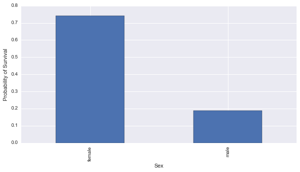

```python
# Probability of survival
sex_group = df.groupby('Sex')
print sex_group['Survived'].describe()
plt = sex_group['Survived'].mean().plot(kind='bar', figsize=(10, 5))
plt.set_ylabel('Probability of Survival')
```

### Sex is the major factor influence the chance of survival a lot. We can see the survival probability of female is 74%, which is a lot more than male's 19%

```
<class 'matplotlib.axes._subplots.AxesSubplot'>
```

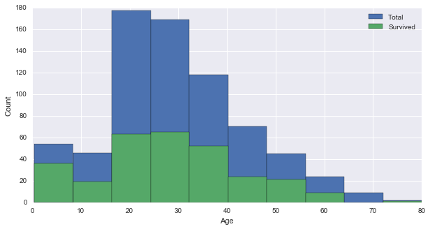

```python
df = df[df['Age'].notnull()]
plt = df['Age'].hist(figsize=(10, 5))
plt = df[df['Survived'] == 1]['Age'].hist()
print type(plt)
plt.set_xlabel('Age')
plt.set_ylabel('Count')
plt.legend(['Total', 'Survived'])
```

### Is survival probability related to Age? From the histogram, we cannot tell because the ratio of survived people is not obvious. Let's do more analysis on it.

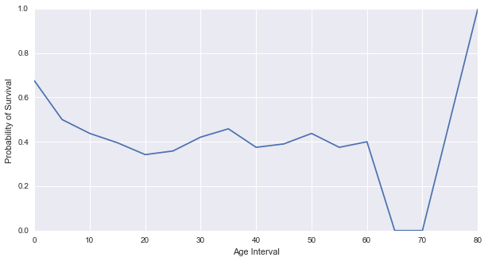

```python
# group passengers by Age range of 5
pd.options.mode.chained_assignment = None
df['Age Interval'] = df['Age'] // 5 * 5
plt = df.groupby('Age Interval').mean()['Survived'].plot(figsize=(10, 5))
plt.set_ylabel('Probability of Survival')
```

### We can see children under age 10 have higher survival probability (>= 50%). And old people (Age >= 65) seem have lower probability. Let's take detail look at it.

```python
print df[df['Age Interval'] >= 65 ]
```

```
     PassengerId  Survived  Pclass                                  Name  \
33            34         0       2                 Wheadon, Mr. Edward H
54            55         0       1        Ostby, Mr. Engelhart Cornelius
96            97         0       1             Goldschmidt, Mr. George B
116          117         0       3                  Connors, Mr. Patrick
280          281         0       3                      Duane, Mr. Frank
456          457         0       1             Millet, Mr. Francis Davis
493          494         0       1               Artagaveytia, Mr. Ramon
630          631         1       1  Barkworth, Mr. Algernon Henry Wilson
672          673         0       2           Mitchell, Mr. Henry Michael
745          746         0       1          Crosby, Capt. Edward Gifford
851          852         0       3                   Svensson, Mr. Johan

      Sex   Age  SibSp  Parch      Ticket     Fare Cabin Embarked  \
33   male  66.0      0      0  C.A. 24579  10.5000   NaN        S
```

[output cut: 23 more lines]

### Among old people, only one of them survived. Old people do have much lower survival probability.

```
count    3.000000
mean     0.458373
std      0.209061
min      0.239437
25%      0.359603
50%      0.479769
75%      0.567841
max      0.655914
Name: Survived, dtype: float64
```

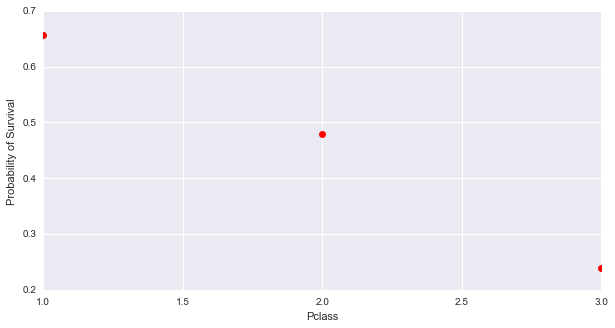

```python
pclass_group = df.groupby('Pclass').mean()['Survived']
print pclass_group.describe()
plt = pclass_group.plot(style='ro', figsize=(10, 5))
plt.set_ylabel('Probability of Survival')
```

### Passenger in First calss have the highest survival probability (65%). 2nd class have less and 3rd class have the least probability (only 25%).

### We have identified theree factors cause the difference on chance of survival. Now let's analyze those factors together.

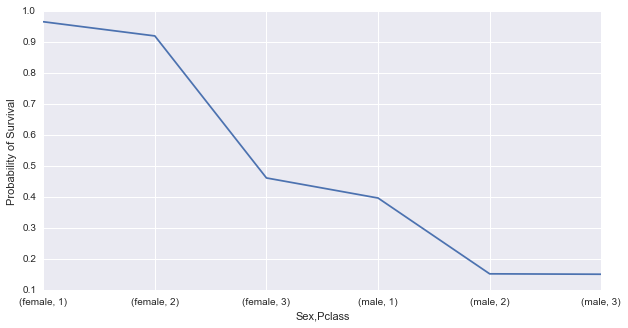

```python
plt = df.groupby(['Sex', 'Pclass']).mean()['Survived'].plot(figsize=(10, 5))
plt.set_ylabel('Probability of Survival')
```